# Notes on Ch 16 - Factors

Norman Lim

2025-07-30

### Prerequisites

```r
library(tidyverse)
```

## Factor Basics

- Disadvantages of using strings to record variables:
1. Prone to typos.
2. It doesn’t sort in a useful way.

Example:

```r
# Intended data
x1 <- c("Dec", "Apr", "Jan", "Mar")

# Data with typo
x2 <- c("Dec", "Apr", "Jam", "Mar")

# sorting is not meaningful here
sort(x1)
```

```
## [1] "Apr" "Dec" "Jan" "Mar"
```

Solution:  
- Convert the data into factor.

Steps:  
1. Create valid levels.  
2. Create a factor.

Demonstration:

```r
# Step 1: create valid levels
month_levels = c(
  "Jan", "Feb", "Mar", "Apr", "May", "Jun",
  "Jul", "Aug", "Sep", "Oct", "Nov", "Dec"
)

# Step 2: create a factor
y1 <- factor(x1, levels = month_levels)
y1
```

```
## [1] Dec Apr Jan Mar
## Levels: Jan Feb Mar Apr May Jun Jul Aug Sep Oct Nov Dec
```

```r
sort(y1)
```

```
## [1] Jan Mar Apr Dec
## Levels: Jan Feb Mar Apr May Jun Jul Aug Sep Oct Nov Dec
```

Disadvantage: - Any values not in the level will be silently converted to `NA`:

```r
y2 <- factor(x2, levels = month_levels)
y2
```

```
## [1] Dec  Apr  <NA> Mar
## Levels: Jan Feb Mar Apr May Jun Jul Aug Sep Oct Nov Dec
```

Better way: - use `forcats::fct()` instead or `factor()` to convert strings into factors:

```r
y2 <- fct(x2, levels = month_levels)
```

Q: What happens when we omit the `levels`? A: For `factor()`, default level will be assigned, in alphabetical order. For `fct()` the default level is sorted according to the order of appearance:

```r
factor(x1)
```

```
## [1] Dec Apr Jan Mar
## Levels: Apr Dec Jan Mar
```

```r
fct(x1)
```

```
## [1] Dec Apr Jan Mar
## Levels: Dec Apr Jan Mar
```

- Levels can be accessed using `levels()`:

```r
levels(y2)
```

```
##  [1] "Jan" "Feb" "Mar" "Apr" "May" "Jun" "Jul" "Aug" "Sep" "Oct" "Nov" "Dec"
```

- When reading data with **readr**, we can create a factor on the spot using `col_factor()`:

```r
csv <- "
month,value
Jan,12
Feb,56
Mar,12"

df <- read_csv(csv, col_types = cols(month = col_factor(month_levels)))
df$month
```

```
## [1] Jan Feb Mar
## Levels: Jan Feb Mar Apr May Jun Jul Aug Sep Oct Nov Dec
```

## Demo with factors using GSS data

```r
gss_cat
```

```
## # A tibble: 21,483 × 9
##     year marital         age race  rincome        partyid    relig denom tvhours
##    <int> <fct>         <int> <fct> <fct>          <fct>      <fct> <fct>   <int>
##  1  2000 Never married    26 White $8000 to 9999  Ind,near … Prot… Sout…      12
##  2  2000 Divorced         48 White $8000 to 9999  Not str r… Prot… Bapt…      NA
##  3  2000 Widowed          67 White Not applicable Independe… Prot… No d…       2
##  4  2000 Never married    39 White Not applicable Ind,near … Orth… Not …       4
##  5  2000 Divorced         25 White Not applicable Not str d… None  Not …       1
##  6  2000 Married          25 White $20000 - 24999 Strong de… Prot… Sout…      NA
##  7  2000 Never married    36 White $25000 or more Not str r… Chri… Not …       3
##  8  2000 Divorced         44 White $7000 to 7999  Ind,near … Prot… Luth…      NA
##  9  2000 Married          44 White $25000 or more Not str d… Prot… Other       0
## 10  2000 Married          47 White $25000 or more Strong re… Prot… Sout…       3
## # ℹ 21,473 more rows
```

- Viewing the levels using `count()`:

```r
gss_cat |>
  count(race)
```

```
## # A tibble: 3 × 2
##   race      n
##   <fct> <int>
## 1 Other  1959
## 2 Black  3129
## 3 White 16395
```

Two most important operations when working with factors: 1. Changing the order of the levels.  
2. Changing the values of the levels.

### Exercises

1. Explore the distribution of `rincome` (reported income). What makes the default bar chart hard to understand? How could you improve the plot.

Ans.

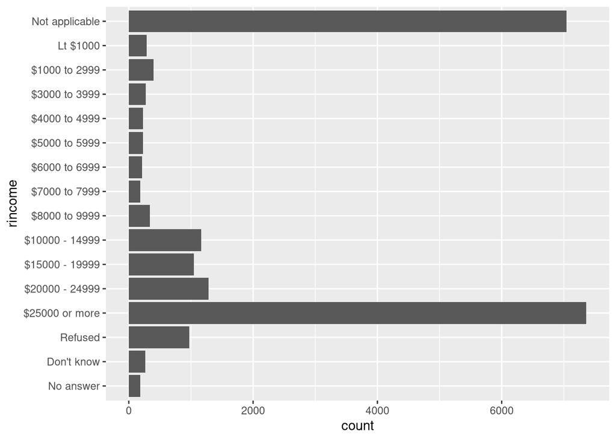

```r
gss_cat |>
  ggplot(aes(x = rincome)) +
  geom_bar() +
  coord_flip()
```

The income were given terms of salary ranges and the labels are long. Flipping the coordinates or using a horizontal bar char would make it easier to understand. Ordering the bars will also make it easier to understand.

2. What is the most common `relig` in this survey? What is the most common `partyid`?

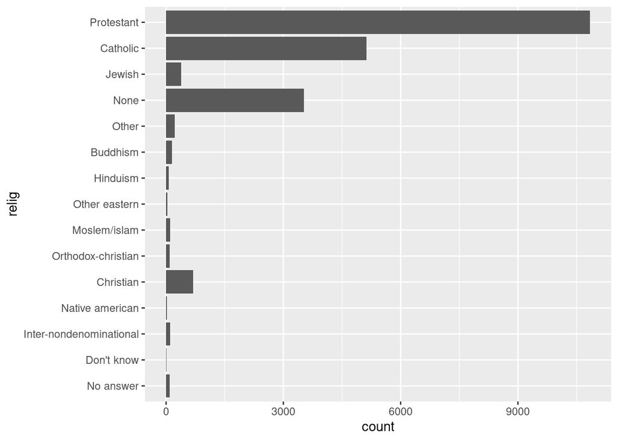

```r
gss_cat |>
  ggplot(aes(x = relig)) +
  geom_bar() +
  coord_flip()
```

Protestant is the most common religion for the respondents.

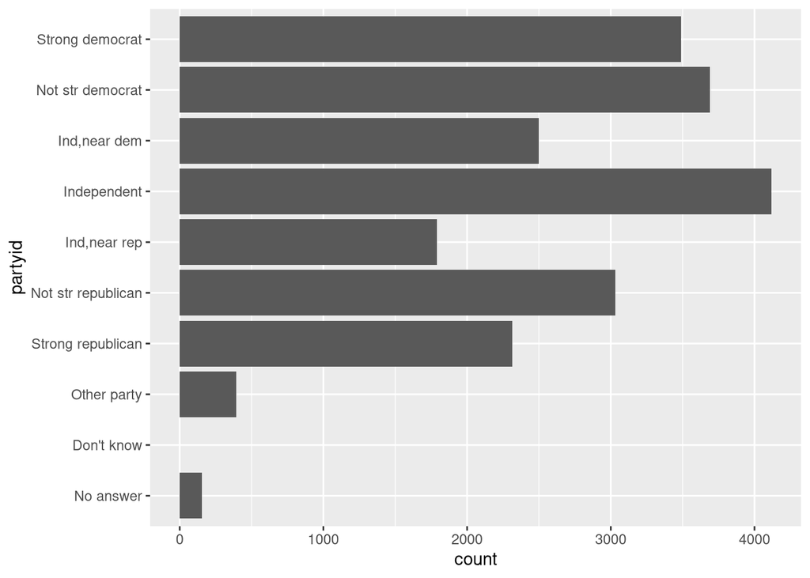

```r
gss_cat |>
  ggplot(aes(x = partyid)) +
  geom_bar() +
  coord_flip()
```

The most common `partyid` is `Independent”.

3. Which `relig` does `denom` (denomination) apply to? How can you find out with a table? How can you find out with a visualization?

table:

```r
table3 <- gss_cat |>
  select(relig, denom) |>
  group_by(relig, denom) |>
  summarize(
    count = n()
  ) |>
  ungroup()
table3
```

```
## # A tibble: 47 × 3
##    relig                   denom           count
##    <fct>                   <fct>           <int>
##  1 No answer               No answer          93
##  2 Don't know              Not applicable     15
##  3 Inter-nondenominational Not applicable    109
##  4 Native american         Not applicable     23
##  5 Christian               No answer           2
##  6 Christian               Don't know         11
##  7 Christian               No denomination   452
##  8 Christian               Not applicable    224
##  9 Orthodox-christian      Not applicable     95
## 10 Moslem/islam            Not applicable    104
## # ℹ 37 more rows
```

data viz:

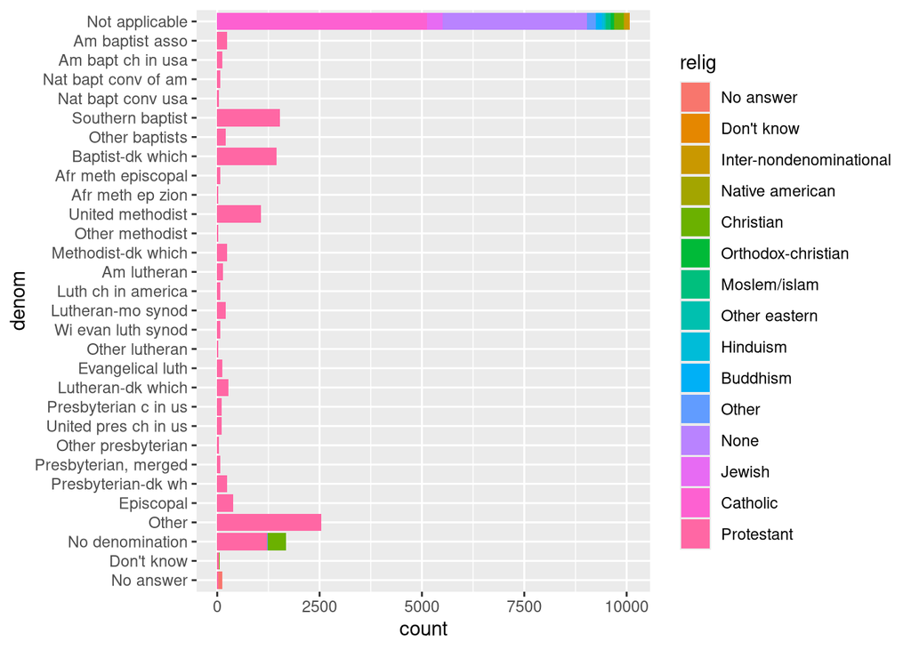

```r
table3 |> ggplot(aes(x = denom, y = count, fill = relig)) +
  geom_col() +
  coord_flip()
```

`denom` refers to the religious sect(?).

## Modifying factor order

Example showing a plot with no sorting order applied:

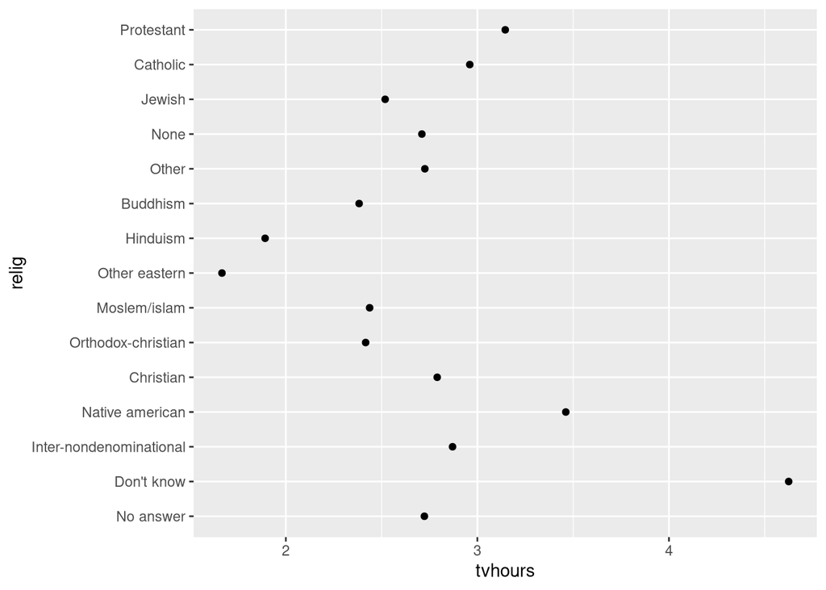

```r
relig_summary <- gss_cat |>
  group_by(relig) |>
  summarize(
    tvhours = mean(tvhours, na.rm = TRUE),
    n = n()
  )

ggplot(relig_summary, aes(x = tvhours, y = relig)) +
  geom_point()
```

The plot is hard to read because there is no overall pattern.

Plot ordered using `fct_reorder()`:

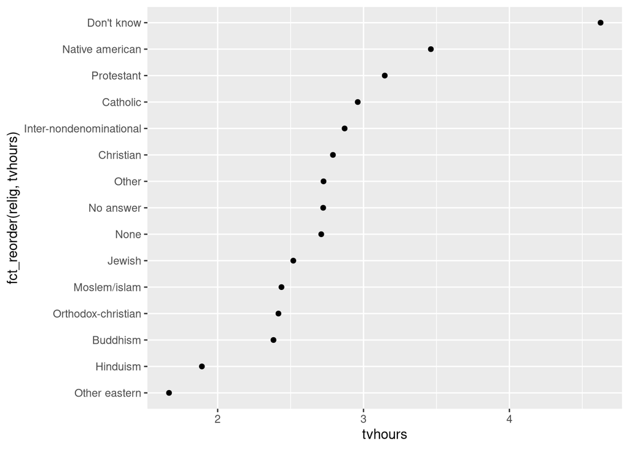

```r
relig_summary |>
  ggplot(aes(
    x = tvhours,
    y = fct_reorder(relig, tvhours)
  )) +
  geom_point()
```

Here `relig` is reordered according to the number of `tvhours`.

- When the transformations are more complicated, is is better to do that inside the `mutate()` function rather than ‘on-the-fly’.

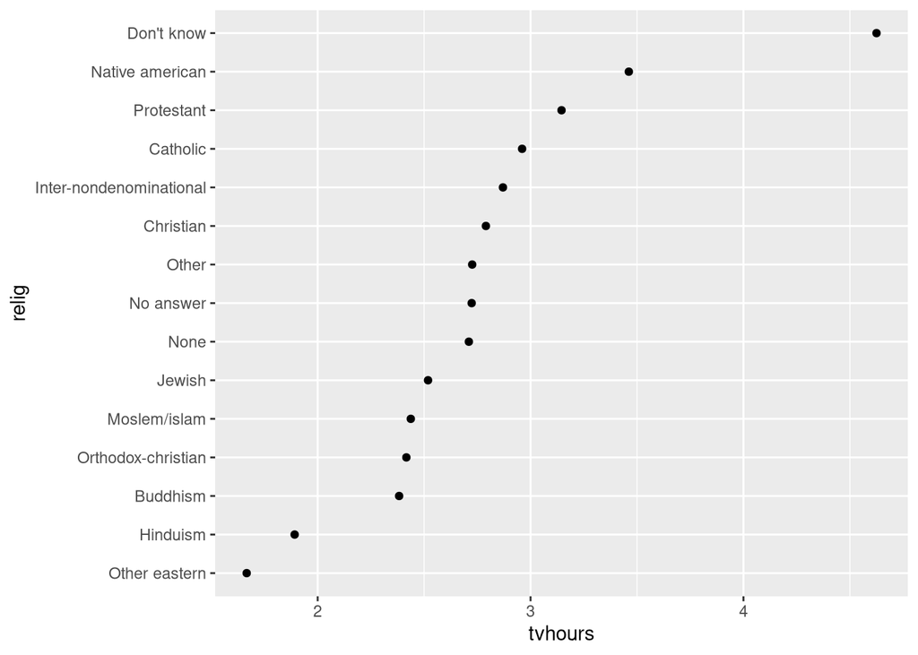

```r
relig_summary |>
  mutate(
    relig = fct_reorder(relig, tvhours)
  ) |>
  ggplot(aes(x = tvhours, y = relig)) +
  geom_point()
```

Plot exploring how the average age varies across reported income levels. Again, `fct_reorder()` was used here.

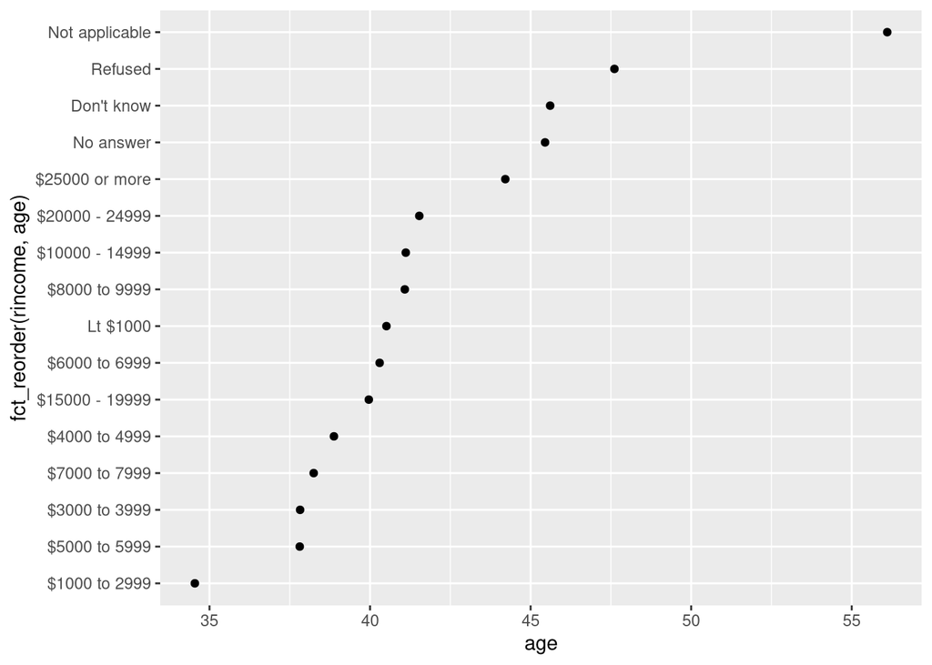

```r
rincome_summary <- gss_cat |>
  group_by(rincome) |>
  summarize(
    age = mean(age, na.rm = TRUE),
    n = n()
  )

rincome_summary |>
  ggplot(aes(
    x = age,
    y = fct_reorder(rincome, age)
  )) +
  geom_point()
```

- This time, the technique or reordering does not work well. This is because `rincome` already has a principled order.
- We should reserve `fct_reorder` for factores whose levels are arbitrarily ordered.
- If there is a sensible level already, and we only want to tweak it a bit, `fct_relevel()` is useful.
- Example where `fct_relevel()` is used to move “Not applicable” to the bottom of the plot:

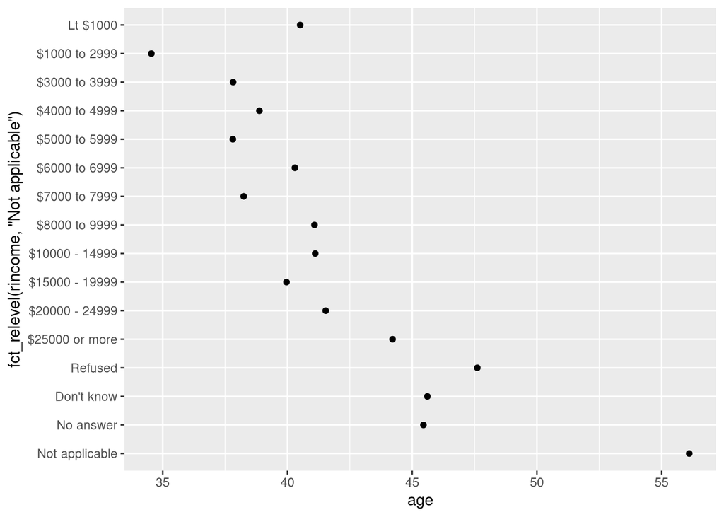

```r
rincome_summary |> ggplot(aes(
  x = age,
  y = fct_relevel(rincome, "Not applicable")
)) +
  geom_point()
```

- Example of using `fct_reorder()` to improve coloring on the plot:

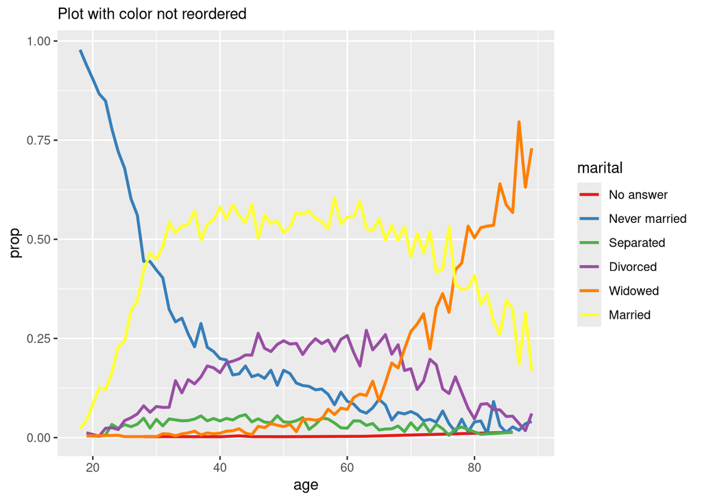

```r
by_age <- gss_cat |>
  filter(!is.na(age)) |>
  count(age, marital) |>
  group_by(age) |>
  mutate(
    prop = n / sum(n)
  )

by_age |> ggplot(aes(
  x = age,
  y = prop,
  color = marital
)) +
  geom_line(linewidth = 1) +
  scale_color_brewer(palette = "Set1") +
  labs(
    subtitle = "Plot with color not reordered"
  )
```

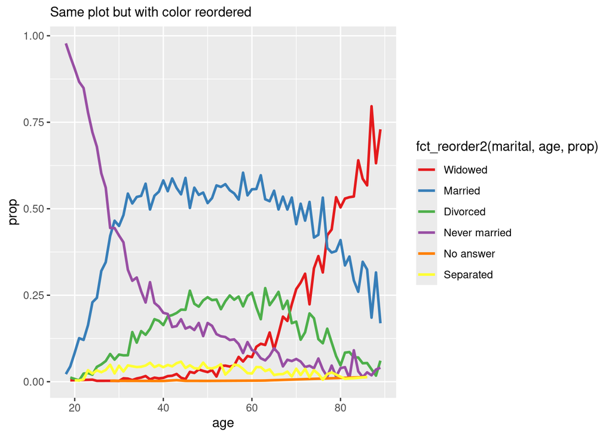

```r
by_age |> ggplot(aes(
  x = age,
  y = prop,
  color = fct_reorder2(marital, age, prop)
)) +
  geom_line(linewidth = 1) +
  scale_color_brewer(palette = "Set1") +
  labs(
    subtitle = "Same plot but with color reordered"
  )
```

- For bar plots, `fct_infreq()` can be used to order levels in decreasing frequency.
- `fct_infreq()` can be paired with `fct_rev()` if you want bar plot rendered in increasing frequency.

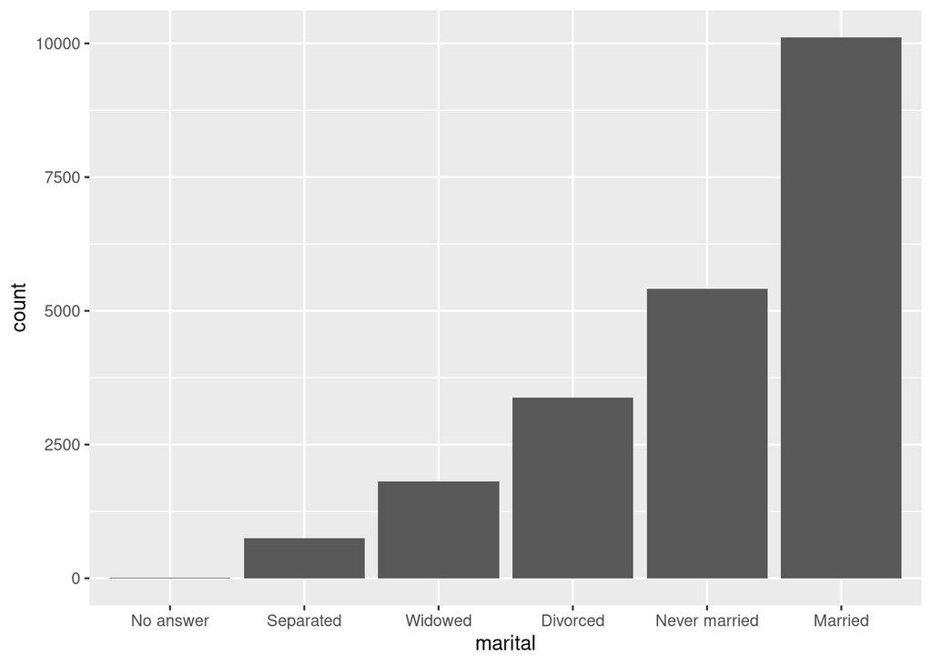

```r
gss_cat |>
  mutate(
    marital = marital |> fct_infreq() |> fct_rev()
  ) |>
  ggplot(aes(x = marital)) +
  geom_bar()
```

### Exercises

1. There are some suspiciously high numbers in `tvhours`. Is the mean a good summary()?

Ans.

```r
relig_summary |>
  arrange(desc(n))
```

```
## # A tibble: 15 × 3
##    relig                   tvhours     n
##    <fct>                     <dbl> <int>
##  1 Protestant                 3.15 10846
##  2 Catholic                   2.96  5124
##  3 None                       2.71  3523
##  4 Christian                  2.79   689
##  5 Jewish                     2.52   388
##  6 Other                      2.73   224
##  7 Buddhism                   2.38   147
##  8 Inter-nondenominational    2.87   109
##  9 Moslem/islam               2.44   104
## 10 Orthodox-christian         2.42    95
## 11 No answer                  2.72    93
## 12 Hinduism                   1.89    71
## 13 Other eastern              1.67    32
## 14 Native american            3.46    23
## 15 Don't know                 4.62    15
```

No. Averaging `tvhours` for each `relig` will not give us a fair result since the number of respondents for each `relig` is so unbalanced – more than 10,000 identified as protestant but only 71 identified as Hindu, for example. Also, there might be other factors at play here, such as economic status and hours spent watching tv.

2. For each factor in `gss_cat`, identify whether the order of the levels is arbitrary or principled.

Ans.

```r
levels(gss_cat$marital)
```

```
## [1] "No answer"     "Never married" "Separated"     "Divorced"
## [5] "Widowed"       "Married"
```

```r
levels(gss_cat$race)
```

```
## [1] "Other"          "Black"          "White"          "Not applicable"
```

```r
levels(gss_cat$rincome)
```

```
##  [1] "No answer"      "Don't know"     "Refused"        "$25000 or more"
##  [5] "$20000 - 24999" "$15000 - 19999" "$10000 - 14999" "$8000 to 9999"
##  [9] "$7000 to 7999"  "$6000 to 6999"  "$5000 to 5999"  "$4000 to 4999"
## [13] "$3000 to 3999"  "$1000 to 2999"  "Lt $1000"       "Not applicable"
```

```r
levels(gss_cat$partyid)
```

```
##  [1] "No answer"          "Don't know"         "Other party"
##  [4] "Strong republican"  "Not str republican" "Ind,near rep"
##  [7] "Independent"        "Ind,near dem"       "Not str democrat"
## [10] "Strong democrat"
```

```r
levels(gss_cat$relig)
```

```
##  [1] "No answer"               "Don't know"
##  [3] "Inter-nondenominational" "Native american"
##  [5] "Christian"               "Orthodox-christian"
##  [7] "Moslem/islam"            "Other eastern"
##  [9] "Hinduism"                "Buddhism"
## [11] "Other"                   "None"
## [13] "Jewish"                  "Catholic"
## [15] "Protestant"              "Not applicable"
```

```r
levels(gss_cat$denom)
```

```
##  [1] "No answer"            "Don't know"           "No denomination"
##  [4] "Other"                "Episcopal"            "Presbyterian-dk wh"
##  [7] "Presbyterian, merged" "Other presbyterian"   "United pres ch in us"
## [10] "Presbyterian c in us" "Lutheran-dk which"    "Evangelical luth"
## [13] "Other lutheran"       "Wi evan luth synod"   "Lutheran-mo synod"
## [16] "Luth ch in america"   "Am lutheran"          "Methodist-dk which"
## [19] "Other methodist"      "United methodist"     "Afr meth ep zion"
## [22] "Afr meth episcopal"   "Baptist-dk which"     "Other baptists"
## [25] "Southern baptist"     "Nat bapt conv usa"    "Nat bapt conv of am"
## [28] "Am bapt ch in usa"    "Am baptist asso"      "Not applicable"
```

marital: arbitrary race: arbitrary rincome: principled partyid: arbitrary relig: arbitrary denom: arbitrary

3. Why did moving “Not Applicable” to the front of the levels move it to the bottom of the plot()

Ans. Horizontal bar charts are rendered in reverse order. This behavior can also be seen in Python, where a table shown in decreasing order would be rendered in increasing order in a bar plot.

## Modifying factor levels

- The most powerful tool for modifying factors is `fct_recode()`.
- `fct_recode()` allows us to recode, or change the value of each level.

Example:

```r
gss_cat |> count(partyid)
```

```
## # A tibble: 10 × 2
##    partyid                n
##    <fct>              <int>
##  1 No answer            154
##  2 Don't know             1
##  3 Other party          393
##  4 Strong republican   2314
##  5 Not str republican  3032
##  6 Ind,near rep        1791
##  7 Independent         4119
##  8 Ind,near dem        2499
##  9 Not str democrat    3690
## 10 Strong democrat     3490
```

The default levels here are inconsistent.

- Tweaking the levels using `fct_recode()`:

```r
gss_cat |>
  mutate(
    partyid = fct_recode(partyid,
      "Republican, strong"    = "Strong republican",
      "Republican, weak"      = "Not str republican",
      "Independent, near rep" = "Ind,near rep",
      "Independent near dem"  = "Ind,near dem",
      "Democrat, weak"        = "Not str democrat",
      "Democrat, strong"      = "Strong democrat"
    )
  ) |>
  count(partyid)
```

```
## # A tibble: 10 × 2
##    partyid                   n
##    <fct>                 <int>
##  1 No answer               154
##  2 Don't know                1
##  3 Other party             393
##  4 Republican, strong     2314
##  5 Republican, weak       3032
##  6 Independent, near rep  1791
##  7 Independent            4119
##  8 Independent near dem   2499
##  9 Democrat, weak         3690
## 10 Democrat, strong       3490
```

- `fct_collapse()` is a useful tool for reducing the number of levels or lumping together some levels:

```r
gss_cat |>
  mutate(
    partyid = fct_collapse(partyid,
      "other" = c("No answer", "Don't know", "Other party"),
      "rep"   = c("Strong republican", "Not str republican"),
      "ind"   = c("Ind,near rep", "Independent", "Ind,near dem"),
      "dem"   = c("Not str democrat", "Strong democrat")
    )
  ) |>
  count(partyid)
```

```
## # A tibble: 4 × 2
##   partyid     n
##   <fct>   <int>
## 1 other     548
## 2 rep      5346
## 3 ind      8409
## 4 dem      7180
```

Example of manually lumping to “Other” some categories:

```r
gss_cat |>
  mutate(
    partyid = fct_recode(partyid,
      "Republican, strong"    = "Strong republican",
      "Republican, weak"      = "Not str republican",
      "Independent, near rep" = "Ind,near rep",
      "Independent, near dem" = "Ind,near dem",
      "Democrat, weak"        = "Not str democrat",
      "Democrat, strong"      = "Strong democrat",
      "Other"                 = "No answer",
      "Other"                 = "Don't know",
      "Other"                 = "Other party"
    )
  ) |>
  count(partyid)
```

```
## # A tibble: 8 × 2
##   partyid                   n
##   <fct>                 <int>
## 1 Other                   548
## 2 Republican, strong     2314
## 3 Republican, weak       3032
## 4 Independent, near rep  1791
## 5 Independent            4119
## 6 Independent, near dem  2499
## 7 Democrat, weak         3690
## 8 Democrat, strong       3490
```

- Example using `fct_lump_*()` family of functions to lump small groups to “Other”:

```r
gss_cat |>
  mutate(
    relig = fct_lump_lowfreq(relig)
  ) |>
  count(relig)
```

```
## # A tibble: 2 × 2
##   relig          n
##   <fct>      <int>
## 1 Protestant 10846
## 2 Other      10637
```

- To control how the small categories are lumped together, we can also use `fct_lump_n()` to tell dplyr how many categories to retain:

```r
gss_cat |>
  mutate(
    relig = fct_lump_n(relig, n = 10)
  ) |>
  count(relig, sort = TRUE)
```

```
## # A tibble: 10 × 2
##    relig                       n
##    <fct>                   <int>
##  1 Protestant              10846
##  2 Catholic                 5124
##  3 None                     3523
##  4 Christian                 689
##  5 Other                     458
##  6 Jewish                    388
##  7 Buddhism                  147
##  8 Inter-nondenominational   109
##  9 Moslem/islam              104
## 10 Orthodox-christian         95
```

### Exercises

1. How have the proportions of people identifying as Democrat, Republican, and Independent changed over time?

Ans.

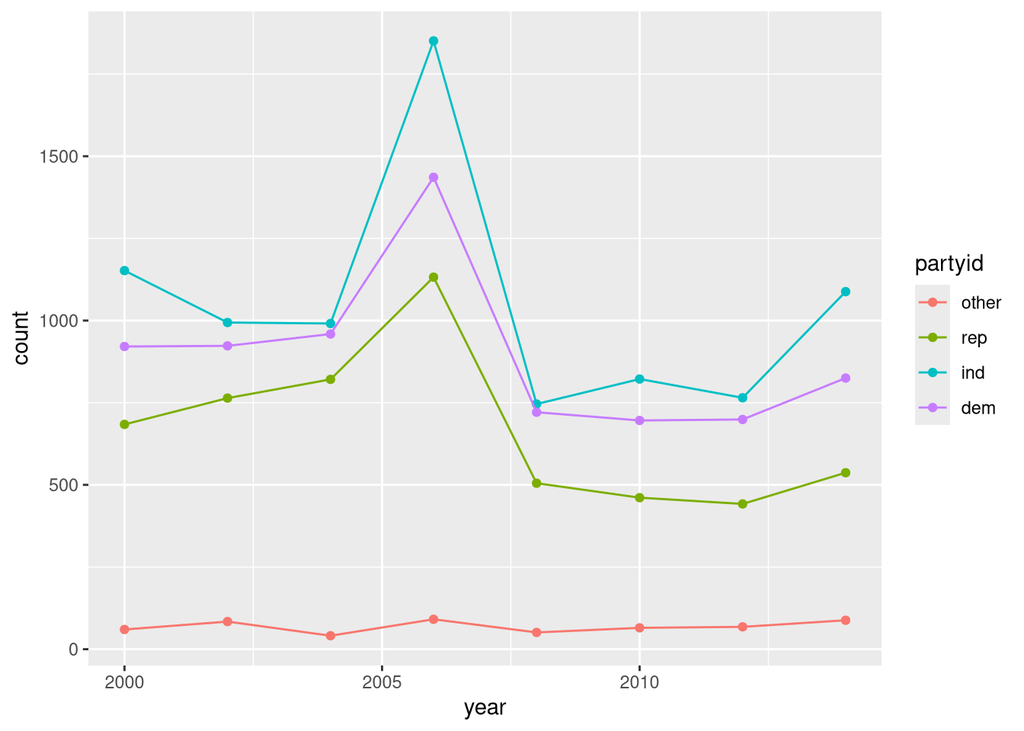

```r
gss_cat |>
  mutate(
    partyid = fct_collapse(partyid,
      "other" = c("No answer", "Don't know", "Other party"),
      "rep"   = c("Strong republican", "Not str republican"),
      "ind"   = c("Ind,near rep", "Independent", "Ind,near dem"),
      "dem"   = c("Not str democrat", "Strong democrat")
    )
  ) |>
  group_by(year, partyid) |>
  summarize(
    count = n()
  ) |>
  ggplot(aes(x = year, y = count, color = partyid)) +
  geom_point() +
  geom_line()
```

2. How could you collapse `rincome` into a small set of categories?

Ans. I would categorize income as low, medium, high, and others using `fct_recode()`

3. Notice there are 9 groups (excluding other) in the `fct_lump` example above. Why not 10?

Ans. Because the default `other_level` for `fct_lump` is considered as a level too.

## Ordered factors

- A ranking can be created for factors using the `ordered()` function:

```r
ordered(c("a", "b", "c"))
```

```
## [1] a b c
## Levels: a < b < c
```

- Ordered factors are particularly useful when mapping colors.